# Entrega III Individual

### Probability Distribution Plot

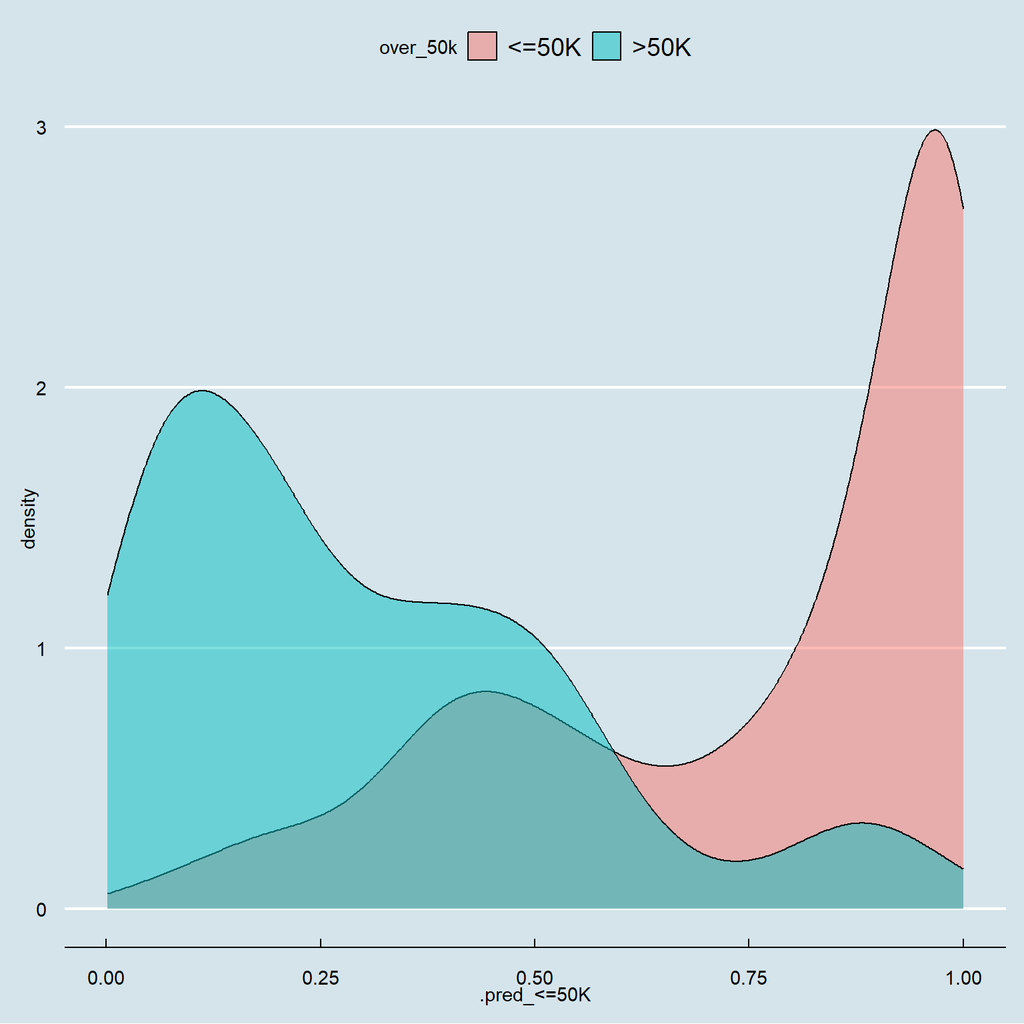

```r
rf_pred |>
  ggplot() +
  geom_density(aes(x = `.pred_<=50K`,
                   fill = over_50k),
               alpha = 0.5) +
  theme_economist()
```

El modelo muestra una gran diferencia entre los dos cúmulos de probabilidades, cada uno inclinándose más hacia un lado y haciendo más certero al modelo.

### Importancia de las variables

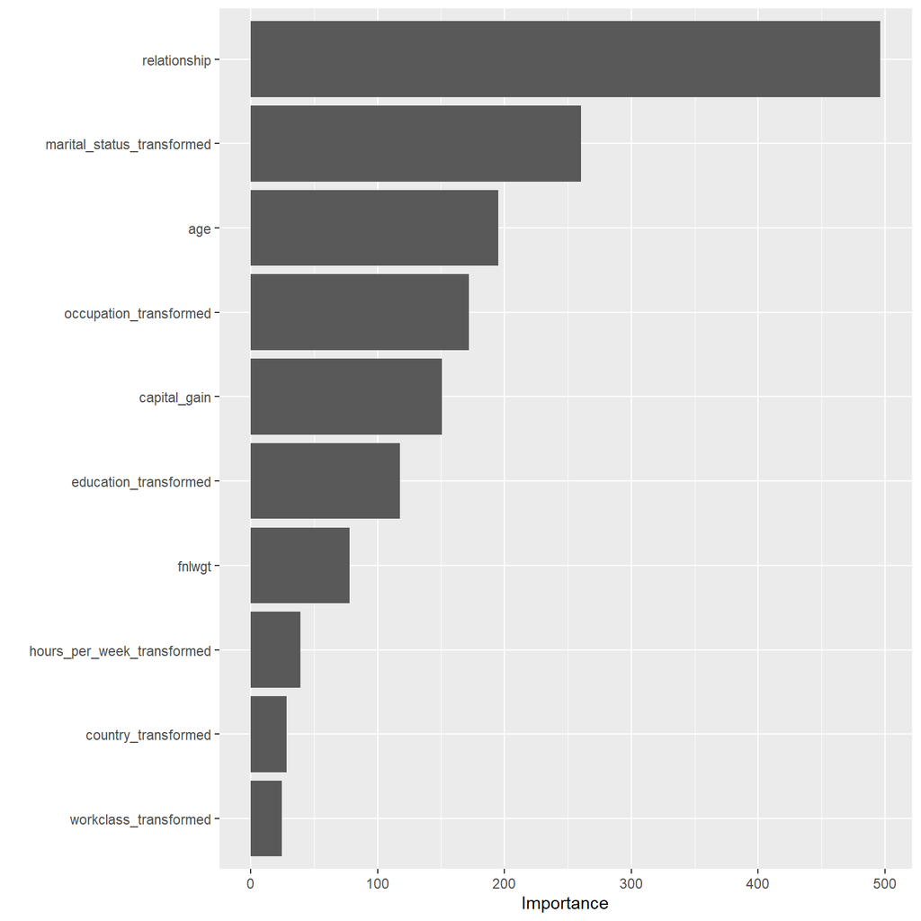

```r
final_rf_fit |>
  pluck(".workflow", 1) |>
  pull_workflow_fit() |>
  vip(num_features = 10)
```

Podemos ver que sigue siendo las dos variables más importantes el estado civil y la relación familiar para determinar el ingreso del individuo.

## Comparación de Modelos

Procederemos a comparar los 3 modelos que anteriormente hemos hecho.

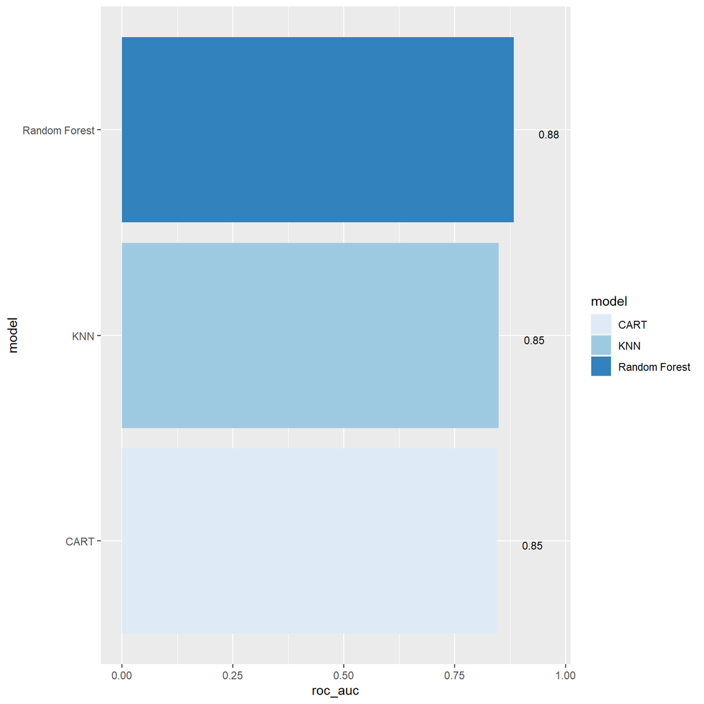

```r
# Resultados Random Forest
rf_metrics <-
  final_rf_fit |>
  collect_metrics(summarise = TRUE) |>
  mutate(model = "Random Forest")

# Resultados Decision Tree
cart_metrics <-
  final_cart_fit |>
  collect_metrics(summarise = TRUE) |>
  mutate(model = "CART")

# Resultados KNN
knn_metrics <-
  final_knn_fit |>
  collect_metrics(summarise = TRUE) |>
  mutate(model = "KNN")

# Juntando resultados
model_compare <- bind_rows(rf_metrics,
                           cart_metrics,
                           knn_metrics,
                           )
# Modelando tabla para resultados
model_comp <-
  model_compare |>
  select(model, .metric, .estimate) |>
  pivot_wider(names_from = .metric, values_from = c(.estimate))


# Graficando resultados
model_comp |>
  arrange(roc_auc) |>
  mutate(model = fct_reorder(model, roc_auc)) |> # Ordenando Resultados
  ggplot(aes(model, roc_auc, fill=model)) +
  geom_col() +
  coord_flip() +
  scale_fill_brewer(palette = "Blues") +
   geom_text(
     size = 3,
     aes(label = round(roc_auc, 2), y = roc_auc + 0.08),
     vjust = 1
  )
```

Siendo el modelo con mejor ROC_AUC el siguiente:

```r
model_comp |> slice_max(n=1, roc_auc)
```

```
# A tibble: 1 × 7
  model         recall precision accuracy  sens f_meas roc_auc
  <chr>          <dbl>     <dbl>    <dbl> <dbl>  <dbl>   <dbl>
1 Random Forest  0.775     0.926    0.782 0.775  0.844   0.883
```

### Comparación Curva ROC

Ahora veamos los resultados en una sola curva ROC.

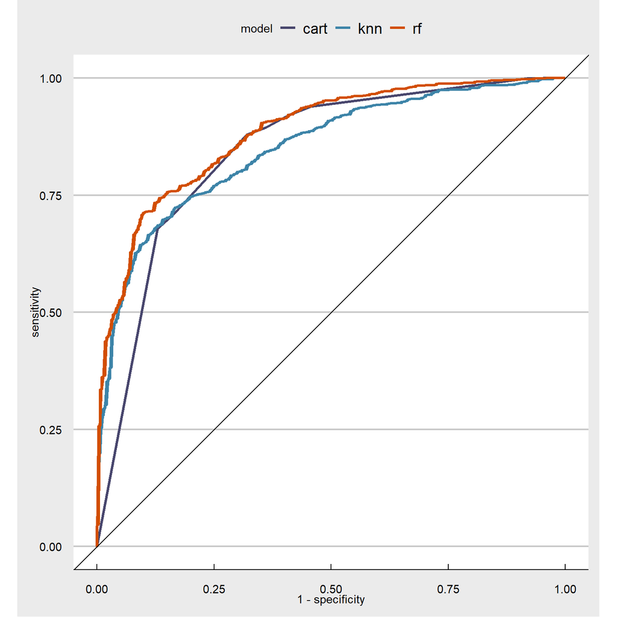

```r
rf_pred_auc <- rf_pred |>  mutate(model= "rf")

cart_pred_auc <- cart_pred |>  mutate(model= "cart")

knn_pred_auc <- knn_pred |>  mutate(model= "knn")

roc_out <- bind_rows(rf_pred_auc, cart_pred_auc,knn_pred_auc)

roc_out %>%
  group_by(model) %>% # Agrupando valores
  roc_curve( truth = over_50k, `.pred_<=50K`) |> # Valores para graficar la curva ROC
  ggplot(
    aes(
      x = 1 - specificity,
      y = sensitivity,
      color = model
    )
  ) + # plot with 2 ROC curves for each model
  geom_line(size = 1.1) +
  geom_abline(slope = 1, intercept = 0, size = 0.4) +
  scale_color_manual(values = c("#48466D", "#3D84A8","#D24E01")) +
  coord_fixed() +
  theme_economist_white()
```

### Validación con repetición

```r
# Declaramos el número de particiones en las que procederemos a validar.
cv_folds <-
 vfold_cv(train_data,
          v = 5,
          strata = over_50k,
          repeats = 2)
```

### Aplicación de flujo de trabajo

Con base a los resultados podemos concluir que el modelo más adecuado es el **Random Forest** con los siguientes parámetros:

```r
# Best Model
rf_fit_tune |> show_best("roc_auc") |> slice_max(mean, n=1)
```

```
# A tibble: 1 × 9
  p_mtry p_trees p_min .metric .estimator  mean     n std_err .config
   <int>   <int> <int> <chr>   <chr>      <dbl> <int>   <dbl> <chr>
1      5      68   122 roc_auc binary     0.889     5 0.00258 Preproc…
```

Con esto podemos optimizar el grid para encontrar el mejor modelo posible:

```r
# Construimos el grid de parámetros
grid_final_rf <-
  parameters(rf_wflow_adultos) |>
  # Actualizamos
  update(p_mtry = mtry(range = c(4, 6)),
         p_min = min_n(range = round(c(0.5, 0.15) * nrow(test_data),0)),
         p_trees = trees(range = c(20, 60))) |>
  grid_regular(levels = 3)


grid_final_rf
```

```
# A tibble: 27 × 3
   p_mtry p_trees p_min
    <int>   <int> <int>
 1      4      20   183
 2      5      20   183
 3      6      20   183
 4      4      40   183
 5      5      40   183
 6      6      40   183
 7      4      60   183
 8      5      60   183
 9      6      60   183
10      4      20   396
# … with 17 more rows
```

Y aplicarlo al flujo de trabajo.

```r
# Aplicamos el flujo
rf_final_fit_tune <-
  rf_wflow_adultos |>
  tune_grid(
    resamples = cv_folds,
    metrics = metric_set(recall, precision, accuracy,roc_auc, sens, f_meas),
    grid = grid_final_rf,
    control = control_grid(verbose = TRUE, allow_par = TRUE, #<<
                                   pkgs = c("outliers")),
 )

# Mejor Modelo
rf_final_fit_tune |> show_best("roc_auc")
```

```
# A tibble: 5 × 9
  p_mtry p_trees p_min .metric .estimator  mean     n std_err .config
   <int>   <int> <int> <chr>   <chr>      <dbl> <int>   <dbl> <chr>
1      4      60   183 roc_auc binary     0.894    10 0.00306 Preproc…
2      4      40   183 roc_auc binary     0.893    10 0.00328 Preproc…
3      5      60   183 roc_auc binary     0.892    10 0.00346 Preproc…
4      4      60   396 roc_auc binary     0.891    10 0.00316 Preproc…
5      5      40   183 roc_auc binary     0.891    10 0.00305 Preproc…
```

```r
# Finalizamos flujo con el mejor modelo (según una métrica)
best_rf_final_model_auc <- rf_final_fit_tune |> select_best("roc_auc")
```

Y finalizamos el cómputo en paralelo. (ya no será necesario)

```r
# finalizamos clusters
stopCluster(make_cluster)
registerDoSEQ()
```

### Selección de Mejor Modelo

Entrenaremos el modelo final con los parámetros del mejor modelo.

```r
final_rf_wf <-
  rf_wflow_adultos |>
  finalize_workflow(best_rf_final_model_auc)

final_rf_fit <-
  final_rf_wf |>
  last_fit(adultos_split,
           metrics = metric_set(recall, precision, accuracy,roc_auc, sens, f_meas))

final_rf_fit |> collect_metrics(summarize = TRUE)
```

```
# A tibble: 6 × 4
  .metric   .estimator .estimate .config
  <chr>     <chr>          <dbl> <chr>
1 recall    binary         0.775 Preprocessor1_Model1
2 precision binary         0.935 Preprocessor1_Model1
3 accuracy  binary         0.788 Preprocessor1_Model1
4 sens      binary         0.775 Preprocessor1_Model1
5 f_meas    binary         0.847 Preprocessor1_Model1
6 roc_auc   binary         0.888 Preprocessor1_Model1
```

### Matriz de Confusión

Visualizemos la matriz de confusión del modelo final

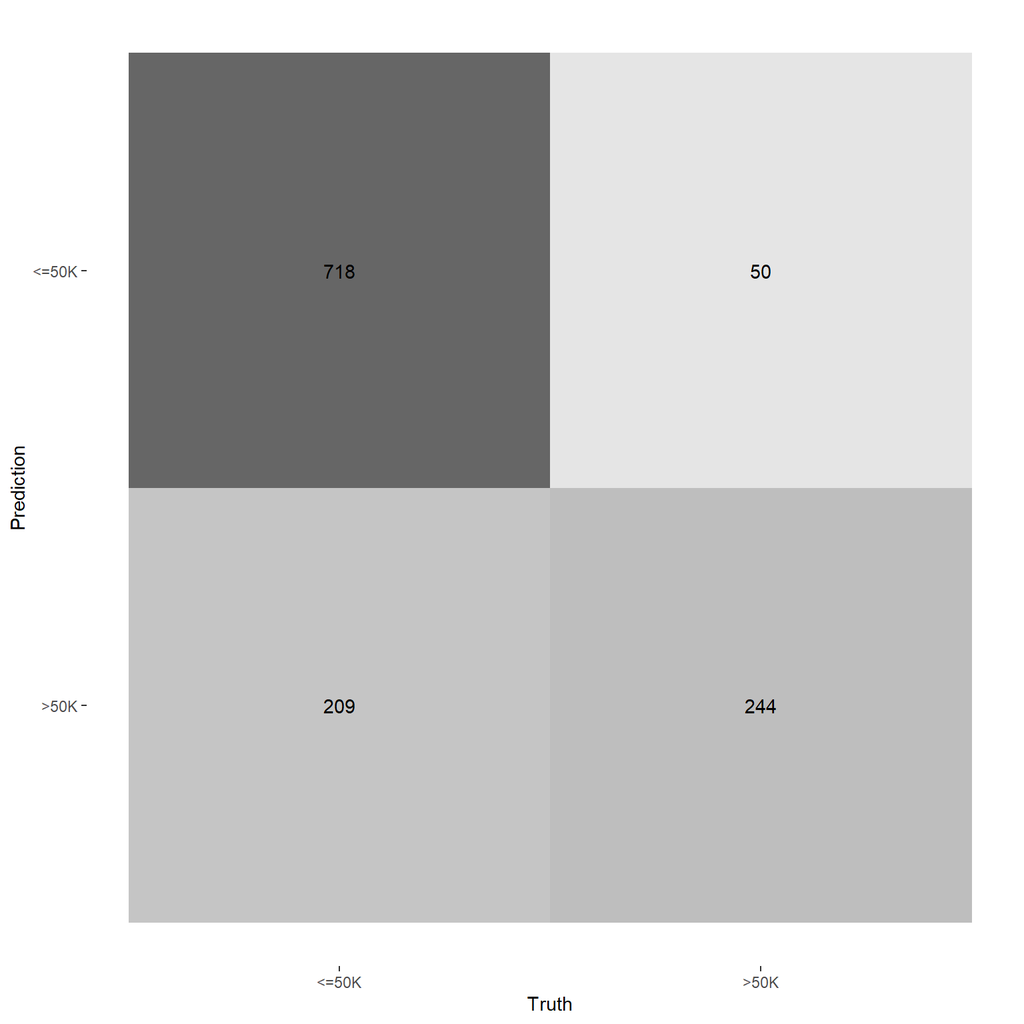

```r
rf_final_pred <-
  final_rf_fit |>
  collect_predictions()


rf_final_pred |>
  conf_mat(over_50k, .pred_class) |>
  autoplot(type = "heatmap")
```

### Probability Distribution Plot

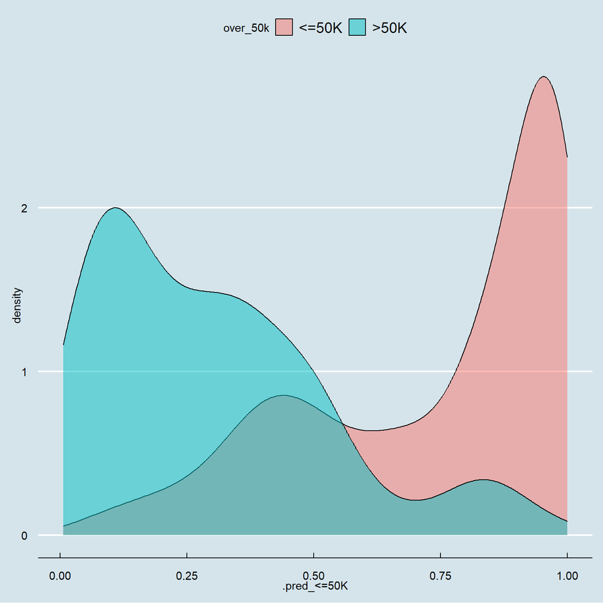

```r
rf_final_pred |>
  ggplot() +
  geom_density(aes(x = `.pred_<=50K`,
                   fill = over_50k),
               alpha = 0.5) +
  theme_economist()
```

Podemos ver que el resultado es muy similiar al pasado Random Forest.

### Comparación entre modelos

Veamos una comparación entre los modelos construidos.

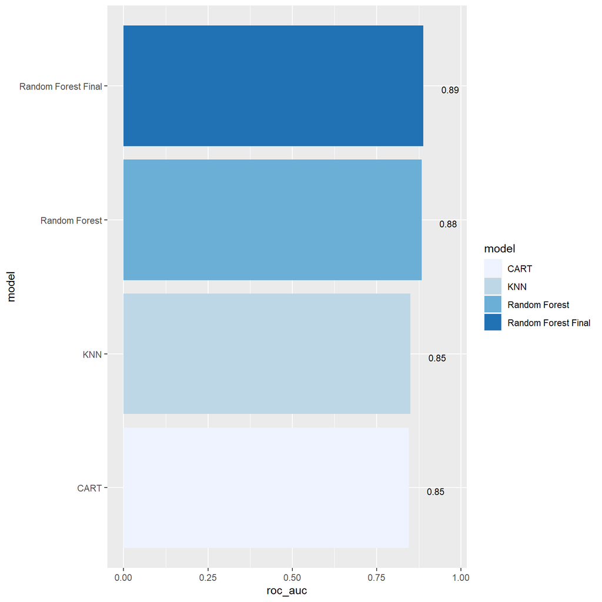

```r
rf_final_metrics <-
  final_rf_fit |>
  collect_metrics(summarise = TRUE) |>
  mutate(model = "Random Forest Final")

model_compare_vf <- bind_rows(model_compare,rf_final_metrics)

model_comp <-
  model_compare_vf |>
  select(model, .metric, .estimate) |>
  pivot_wider(names_from = .metric, values_from = c(.estimate))


model_comp |>
  arrange(roc_auc) |>
  mutate(model = fct_reorder(model, roc_auc)) |> # order results
  ggplot(aes(model, roc_auc, fill=model)) +
  geom_col() +
  coord_flip() +
  scale_fill_brewer(palette = "Blues") +
   geom_text(
     size = 3,
     aes(label = round(roc_auc, 2), y = roc_auc + 0.08),
     vjust = 1
  )
```

El modelo final tiene un AUC score un poco más alto que el pasado Random Forest.

### Curva ROC entre modelos

Ahora visualizemos la curva ROC de nuestros 4 modelos.

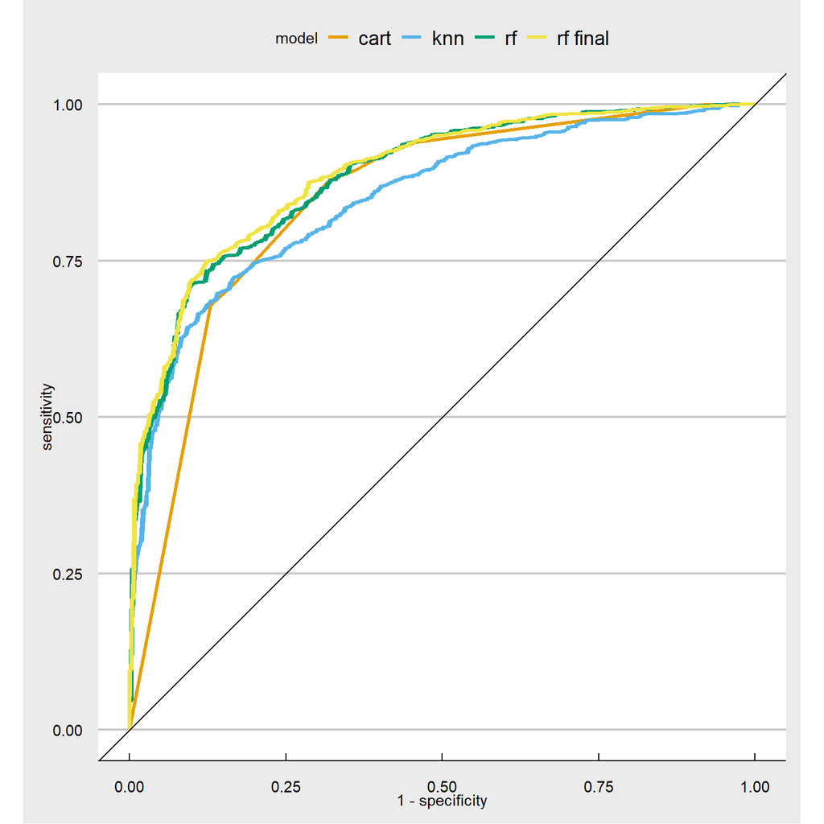

```r
rf_final_pred_auc <- rf_final_pred |>  mutate(model= "rf final")


roc_out_final <- bind_rows(rf_final_pred_auc, roc_out)

roc_out_final %>%
  group_by(model) %>% # group to get individual ROC curve for each model
  roc_curve( truth = over_50k, `.pred_<=50K`) |> # get values to plot an ROC curve
  ggplot(
    aes(
      x = 1 - specificity,
      y = sensitivity,
      color = model
    )
  ) + # plot with 2 ROC curves for each model
  geom_line(size = 1.1) +
  geom_abline(slope = 1, intercept = 0, size = 0.4) +
  scale_color_manual(values = c("#E69F00", "#56B4E9", "#009E73", "#F0E442")) +
  coord_fixed() +
  theme_economist_white()
```